# Do countries bounce back?

Investigating the effect of COVID-related policies on mobility

Frida von Zahn

5/20/2022

```r
knitr::opts_chunk$set(echo = TRUE)
library(tidyverse)
library(lubridate)
library(openair)
library(stargazer)
library(ggThemeAssist)
library(gridExtra)
library(plm)
```

# 1 Research idea and design

## 1.1 Introduction

(Wordcount: 3231 words + 2 visualizations + commented code)

How do people return to normal life after a global pandemic? Social distancing measures, closures of schools and workplaces, limits on large gatherings, and stay-at-home policies have hugely impacted mobility across European countries during the COVID-19 pandemic. However, despite the recent surge in Omicron cases, some countries have lifted restrictions. Countries such as Denmark even lifted all restrictions at once (Crist, 2012). Whilst effective measures are usually welcomed, it is similarly to be hoped that societies show resilience to the heavy encroachments on personal liberties during extraordinary states such as the pandemic. Imposing these measures therefore implies the assumption that countries can bounce back to a previous state once the catastrophe is over. However, other studies suggest that resilience is not as straightforward as suggested. For example, pandemic-induced unemployment also affects early childhood health and reduces the expected lifespan by 5 percent. Furthermore, decreased physical and mental health, unemployment, and financial instability can all effect mobility on longer term than just through COVID-related policies. Woskie et al. (2021) demonstrate that countries experience a significant decrease in mobility right after mandatory COVID measures. Hence, whilst policies aiming at decreasing mobility and reduce the risk of infection seem to work as planned, it is unsure whether lifting these policies similarly increases mobility again. Being able to identify the impact of measures on mobility in different domains such as work/ recreational activities would provide a basis for more in-depth research on the mechanisms that affect mobility beyond the immediate measures. The research question is therefore as follows: *How does the lifting of mobility related policies affect the mobility of citizens in countries that lift COVID restrictions?*

## 1.2 Mechanism and Relevance

It is thereby assumed that, just as Woskie et al. (2021) suggest, there is a relationship between COVID measures and mobility precisely because the former target mobility through either voluntary or mandatory compliance. Similarly, when these measures are lifted, it is assumed that mobility will increase again to the base level, unless there are unobserved moderating and mitigating factors through the pandemic. Even though it is not the focus of this study to identify these ‘COVID-related side-effects’, a very slow return to baselevels or no return at all would indicate such effects. Hence, this research provides a potential basis to identify mobility-related side-effects in future research. It would further justify other policies targeted at reaching base-level mobility again for those groups heavily affected by the pandemic. For example, research by Tsamakis et al. (2021) suggest severe mental health implications for elderly, vulnerable groups, and socially disadvantaged groups such as homeless people and refugees. A study by Kuhn et al. (2020) further argues that there are disparate effects of financial instability between men and women, and people without a partner. Policies targeting at securing physical health or financial aid for certain groups can therefore help to mitigate some of these effects. Identifying mobility patterns before and after the lift of all COVID-related policies can therefore be an important indicator for these effects.

## 1.3 Research Design

These days provide an interesting entry point since they allow us to compare mobility before and after these lifts. Hence, in all countries, the change in mobility before and after the lift is of interest to this study. It is therefore expected that mobility increases in all these countries after the lift of these policies. To establish this effect causally, however, a Difference-in-Differences design was chosen. This way, the mobility data of each country in 2022 could be compared to 2021 as its own control group. In a difference-in-differences estimation, country-fixed effects were added to account for variations related to country differences. This leaves us with the following variables of interest:

- Pre-treatment mobility: mobility before the lift of policies
- Post-treatment mobility: mobility after the lift of policies
- Period: a dummy variable indicating the time period before and after the lift
- Year: the year 2021 (control) or 2022 (treatment) as a dummy

To identify the difference-in-differences estimator, mobility is regressed over treatment/ control, the period, and an interaction of both. The interaction effect yields the difference-in-differences estimator. This leaves us with the following hypothesis:

**H1**: *The difference-in-differences estimator, that is, the difference between change in mobility after compared to before the lift of policies in 2021 and 2022 is positive – indicating a positive significant influence of the lift of all policies on mobility.*

The following section elaborates on the concrete data used, as well as the operationalization of the variables above and additional control variables used for the regression.

## 1.4 Methodology and Data

To compare pre- and post-lift data, a period of five weeks was chosen before and after the lift. Over these five weeks, an average of mobility was taken for each region in both years. This design of using 2021 as a control group for 2022 allows us to assume parallel trends in mobility to a certain degree. Hence, despite changes in weather, we would see an overall similar trend of mobility over the same ten weeks in 2021 and 2022. The five weeks were further chosen based on the design by Woskie et al. (2021). It is assumed that the effects of the lift do not take place instantaneously as people require some time to get used to them and organizations need time to, for example, accommodate more people at a higher frequency. However, an additional regression with a three-week period was added to control for any significance solely based on the window of five weeks. This regression, however, did not yield hugely different results as can be seen in the annex.

The second dataset used is the Coronanet Dataset as provided by the Coronanet project (Cheng et al., 2020). This dataset contains information on the policies in place in different countries during the Covid pandemic. This dataset is used to determine the duration, number, and types of policies in place in the different countries. From this dataset, a control variable was created to account for the number of policies in place in a country at the time of the lift and at the same time in 2021. For this end, an aggregate number of policies in place during the month before the lift (in both years) was added to the final dataset. This way, we can account for differences in the effect of the lift: if a country did not have many policies in place before the lift, the effect on mobility is expected to be weaker.

```r
# A quick comment on my code:
# I know that a lot of things I did in this code are somewhat unnecessary and repetitive and I could've found many shortcuts. However, they are the result of many trial and error sessions and I hope i have commented on them sufficiently to still explain my reasoning. The whole thing with creating numerous datasets is annoying and I could have saved many lines of code, but it is working for now and I do not have much time left to make it slimmer. Efficient coding could be a nice goal for the future, but for now I hope you can still follow my reasoning despite the massive chunks of code.


## Load Google Mobility Dataset:
Gmobility <- read.csv('Global_Mobility_Report.csv', stringsAsFactors = F)

#Extract EU countries of interest and set date to date class
Gmobility_EU <- Gmobility[Gmobility$country_region %in% c(
   "Austria", "Belgium", "Bulgaria",
  "Cyprus","Denmark","Finland","France",
  "Hungary", "Ireland" ,"Luxembourg",
  "Netherlands", "Poland", "Romania",
  "Slovenia","Sweden", "United Kingdom"), ] %>%
  mutate(date=ymd (date))

#making it smaller
Gmobility_EU <- Gmobility_EU %>% subset (date>=as.Date("2021-01-01"))
#creating two new summarized variables for mobility
Gmobility_EU$not_home <- Gmobility_EU$residential_percent_change_from_baseline * (-1) #mobility outside of home
Gmobility_EU$places <- rowMeans(Gmobility_EU[ , c(10,14)], na.rm=TRUE) #mobility at all other places summarized
Gmobility_EU$no_year <- format (as.Date(Gmobility_EU$date), "%m-%d")
Gmobility_EU$year <- year(Gmobility_EU$date)
Gmobility_EU$dummyy <- ifelse(Gmobility_EU$year == "2022",1,0) # dummy variable for year
Gmobility_EU$dummyd <- ifelse(Gmobility_EU$date >= as.Date("2022-03-14"), 1,0) # dummy variable for before/ after lift
Gmobility_EU %>% group_by(no_year) %>% summarise_at(vars(places),list(name = mean),na.rm = TRUE)

# Load Coronanet policy_dataset
CNET <- readRDS('coronanet_release.RDS')

# select countries that have lifts
CNET_EU <- CNET[CNET$country %in% c(
   "Austria", "Belgium", "Bulgaria",
  "Cyprus","Denmark","Finland","France",
  "Hungary", "Ireland" ,"Luxembourg",
  "Netherlands", "Poland", "Romania",
  "Slovenia","Sweden", "United Kingdom"), ] %>%
  select (record_id, policy_id, description, date_start, date_end, country, ISO_A3, type)

#create dataframe for the day of the lift
country <- c(
  "Austria", "Belgium", "Bulgaria",
  "Cyprus","Denmark","Finland","France",
  "Hungary", "Ireland" ,"Luxembourg",
  "Netherlands", "Poland", "Romania",
  "Slovenia","Sweden", "United Kingdom")

lift2 <- as.Date(c(
  "2022-03-05", "2022-03-07", "2022-03-20",
  "2022-02-21", "2022-02-17", "2022-02-01",
  "2022-03-14", "2022-03-07", "2022-02-28",
  "2022-03-11", "2022-03-11","2022-03-23",
  "2022-03-01", "2022-03-09", "2022-02-21",
  "2022-03-18"
))

#add new end dates and mark lift as end date if NA
lifts <- data.frame(country,lift2)

CNET_EU <- CNET_EU %>% left_join(lifts, by = "country")

CNET_EU <- CNET_EU %>%
  mutate(date_end0 = if_else(is.na(date_end), lift2, date_end))


#summarizing number of policies in place in the month before lift (later used as control variable)

CNET_EU$year <- year(CNET_EU$date_end0) #add variable without year for before and after policy to merge datasets afterwards
CNET_count <-  CNET_EU %>%
  filter(date_end0 <= as.Date(lift2) &
           date_end0 >= (as.Date(lift2) - 30)) %>% #selects 30 days before lift in 2022
  group_by(country) %>%
  add_count(country) %>%
  select (country, n, year)

CNET_count2 <- CNET_EU %>%
  filter(date_end0 <= (as.Date(lift2)- 365) &
           date_end0 >= (as.Date(lift2) - 395)) %>% #selects 30 days before "lift" in 2021
  group_by(country) %>%
  add_count(country) %>%
  select (country, n, year)


CNET_merge <- rbind(CNET_count,CNET_count2) %>%
  unique() %>%
  group_by(country)  %>%
  mutate(country_region = country) %>%  #to merge to mobility later
  mutate(Treco = ifelse (year == 2022, 1, 0))



#merge mobility dataset with lift_dates
lifts <- lifts %>%
  mutate(country_region = country)

EU <- Gmobility_EU %>% left_join(lifts, by = "country_region")

#Now, four datasets are created:
#EU1 includes the variable "not_home", which indicates the percentage change in time spent away from home
#EU2 includes the variable "places" which indicates the percentage change in time spent at the different types of places in the dataset
#EU3 includes the the variable "not_home" and the control variable for policies in place in the month before the lift
#EU3 includes the the variable "places" and the control variable for policies in place in the month before the lift

#EU_1 DataWrangling
EU_between <- EU %>%
  mutate(lift_complete = if_else(year == 2022, as.Date(lift2), as.Date(lift2-years(1)))) %>% #equalizes days from final lift in both years
  group_by(sub_region_1) %>%
  mutate(ft = row_number()) %>%
  mutate(event_ft = ifelse(lift_complete == date, ft, NA)) %>%
  fill(event_ft, .direction = "updown") %>%
  mutate(EventTime = ft - event_ft) %>%  #creates a count for days before and after the lift in all years
  select(-event_ft, -ft) %>%
  ungroup() %>%
  filter(EventTime <= 35 &
           EventTime >= -35) %>%  #selects a five-week period before and after lift to average over
  mutate (Treco = ifelse (year == 2022, 1, 0)) %>%
  mutate(PrePost = ifelse(EventTime < 0, 0, 1)) %>%
  group_by(sub_region_1,Treco, PrePost) %>%
  summarize(average = mean(not_home, na.rm =T)) %>%
  mutate(treatment = ifelse(PrePost== 0, "pre", "post")) %>%
  mutate (region = paste(sub_region_1,Treco)) #creates summary columns for each region for pre/ post period

#intermission to add country column to final dataset
countries_regions <- EU %>% select (country_region, sub_region_1) %>%
  distinct()
after_mutation <- EU_between %>% select (sub_region_1, region) %>%
  distinct()
EU_try <- countries_regions %>% left_join (after_mutation, by = "sub_region_1")

EU_u <- EU_between %>% #widens data for visualization
  pivot_wider (id_cols = region,
               names_from = treatment,
               values_from = average,
               unused_fn = list(Treco = max)) %>%
  mutate(change = post - pre) # adds variable that measures change between pre and post treatment

EU_1 <-  EU_u %>% left_join (EU_try, by = c("region", "Treco")) #merges countries to dataset

EU_1 <- na.omit(EU_1) #deletes nas

#turning it into long format for regression
 EU_1_long <-  EU_1 %>%
   pivot_longer(cols = c(pre, post), names_to = "period", values_to = "mobility") %>% # grab columns, put names to new variable period and values to new variable mobility
  mutate(after_lift = if_else(period == "post", 1, 0))

#EU_2: DataWrangling with "places" variable
EU_2between <- EU %>%
  mutate(lift_complete = if_else(year == 2022, as.Date(lift2), as.Date(lift2-years(1)))) %>% #equalizes days from final lift in both years
  group_by(sub_region_1) %>%
  mutate(ft = row_number()) %>%
  mutate(event_ft = ifelse(lift_complete == date, ft, NA)) %>%
  fill(event_ft, .direction = "updown") %>%
  mutate(EventTime = ft - event_ft) %>%  #creates a count for days before and after the lift in all years
  select(-event_ft, -ft) %>%
  ungroup() %>%
  filter(EventTime <= 35 &
           EventTime >= -35) %>%  #selects a five-week period before and after lift to average over
  mutate (Treco = ifelse (year == 2022, 1, 0)) %>%
  mutate(PrePost = ifelse(EventTime < 0, 0, 1)) %>%
  group_by(sub_region_1,Treco, PrePost) %>%
  summarize(average = mean(places, na.rm =T)) %>%
  mutate(treatment = ifelse(PrePost== 0, "pre", "post")) %>%
  mutate (region = paste(sub_region_1,Treco)) #creates summary columns for each region for pre/ post period

#intermission to add country column to final dataset
countries_regions <- EU %>% select (country_region, sub_region_1) %>%
  distinct()
after_mutation <- EU_2between %>% select (sub_region_1, region) %>%
  distinct()
EU_try <- countries_regions %>% left_join (after_mutation, by = "sub_region_1")

EU_u2 <- EU_2between %>% #widens data for visualization
  pivot_wider (id_cols = region,
               names_from = treatment,
               values_from = average,
               unused_fn = list(Treco = max)) %>%
  mutate(change = post - pre) # adds variable that measures change between pre and post treatment

EU_2 <-  EU_u2 %>% left_join (EU_try, by = c("region", "Treco")) #merges countries to dataset

EU_2 <- na.omit(EU_2) #deletes nas to create same length of variables for regression

#turning it into long format for regression
 EU_2_long <-  EU_2 %>%
   pivot_longer(cols = c(pre, post), names_to = "period", values_to = "mobility") %>% # grab columns, put names to new variable period and values to new variable mobility
  mutate(after_lift = if_else(period == "post", 1, 0))


# EU_3: Adding policies as control variable with not_home
EU_3 <- EU_1_long %>% left_join (CNET_merge, by = c("country_region", "Treco")) %>%
  unique() %>%
  mutate(policies = n)

#EU_4: Adding policies as control variable with places
EU_4<- EU_2_long %>% left_join (CNET_merge, by = c("country_region", "Treco")) %>%
  unique() %>%
  mutate (policies = n)
```

## 1.5 Limitations

This research design leaves us with several limitations. Firstly, even though the parallel trends assumption needed for a Diff-in-Diff design was attempted to be satisfied by comparing each region to itself, irregularities cannot be ruled out. An example for such an irregularity could be seasonal changes in weather. It could be, for example, that the weeks after the lift in 2022 were suddenly much sunnier than in 2021, in which case our model would pick up weather changes rather than the effect of the lift on mobility. Furthermore, these irregularities could also stem from changes in policies that took place in 2021. These potential violations are not accounted for in this research design and should be addressed in future research.

Furthermore, the number of policies in place in the month before the lift provides only a rough measure to control for. This variable could have been specified to account for different types of policies, their target country/ region, and whether it is a voluntary or mandatory measure. By only including a count of policies, it is possible to have included policies that do not target the region in question or affect mobility less than others. The Coronanet dataset provides numerous measures to account for these differences and include several control variables. Therefore, future research could make use of the dataset to a much greater degree than this paper does.

Lastly, in order to define the number of policies lifted in each country, a way had to be found to account for the time lag in coding these policies. For example, it is very well possible that a policy ended on March 5th 2022, but the dataset does not specify and end date yet. Therefore, all policies that did not have a specified end date in the Coronanet dataset were coded as having the date of the lift as an end date. In total, 2822 of 6500 end dates were affected by this. This accounts for a time lag in coding, but it also treats policies with little information available as lasting longer than they could have lasted. This way there is no accurate measure to determine whether a policy actually ended much earlier and simply did not have a specified end date in the dataset. Even though one could neglect this limitation as it might affect all countries equally, hence overestimating the number of policies equally, it is likely that this is not the case here. Since the policies are coded manually in the Coronanet dataset, small countries that provide little information in English are likely to have missing entries in the dataset. It is therefore assumed that these countries are now disproportionally affected by the recoding of end dates. Future research could therefore find different measures to re-code these missing values. One way could be to take an average of the time a policy is usually in place per country or type of policies and re-code the end date accordingly.

# 2 Analysis

## 2.1 Descriptive Visualization

The box plot shows the change in mobility for 2021 on the left side and 2022 on the right side. One can see that both boxplots show a positive mean, however, a difference is difficult to estimate. Furthermore, 2021 shows a number of positive outliers whilst 2022 shows a number of negative outliers. These differences could stem from various different reasons: a change of weather, events taking place only every few years such as elections, or previous lifts of harsh policies such as a lockdown in 2021.

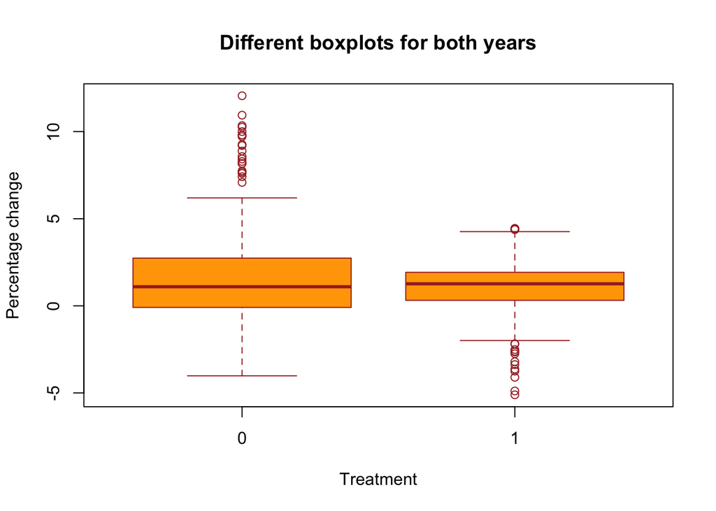

```r
#exploring the data visually: boxplot
boxplot(change~Treco,
data=EU_1,
main="Different boxplots for both years",
xlab="Treatment",
ylab="Percentage change",
col="orange",
border="brown"
)
```

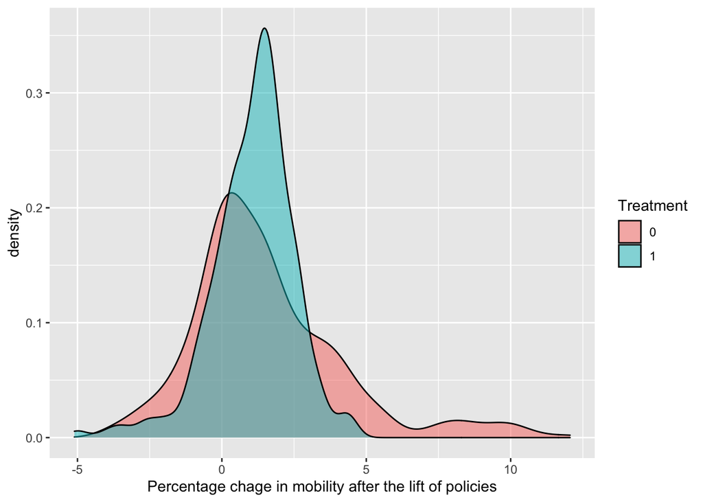

```r
#exploring the data visually: density plot
EU_1 %>%
  ggplot(aes(x = change, fill = factor(Treco))) +
  geom_density(alpha = 0.5) +
  labs(x = "Percentage chage in mobility after the lift of policies",
       fill = "Treatment")
```

## 2.2 Results

To identify the diff-in-diff estimator, four different models in two stages were used. In the first stage, model (1) makes use of the variable *not_home* and model (2) makes use of the variable *places*. Model (1) includes 1.560 observations and has an R2 of 0.496. The binary variable *Treco*, a binary variable indicating the year, with a statistical significant effect of 5.535 tells us that mobility was 5.535 percent higher in 2022 compared to 2021. *After_lift*, a binary variable indicating the time period before and after the lift in both years, tells us that mobility was 1.534 % higher after the lift as compared to before the lift – in both years. The interaction effect, however, is negative and statistically insignificant. Since a negative influence of the lift is unlikely, it is more probable that mobility in 2021 was overall lower due to COVID-related policies in place. The increase in mobility due to *after_lift* in both years could be further explained by seasonal changes since all policy lifts take place between February and April, making more mobility more likely in after-lift-period. Similar results can be seen in model (2). Here, *Treco* shows a significant increase of 20.831 %. This result could be explained by possible lockdowns in place in several European countries during the first half of 2021. Hence, people were allowed to leave the house, but schools, businesses, and recreational sights were closed. The model indicates a negative interaction effect of -0.243, too, which is equally insignificant and implausible.

```r
#regression models:
#Not_home regression with country fixed effects
did_1_model <- plm(mobility ~ Treco + after_lift + Treco*after_lift,
                                  data=EU_1_long, index = c ("country_region"), model = "within")

#places regression with country fixed effects
did_2_model <- plm(mobility ~ Treco + after_lift + Treco*after_lift,
                                  data=EU_2_long, index = c ("country_region"), model = "within")

#not_home regression with control
did_3_model <- plm(mobility ~ Treco + after_lift + Treco*after_lift +policies,
                                  data=EU_3, index = c ("country_region"), model = "within")

#places regression with control
did_4_model <- plm(mobility ~ Treco + after_lift + Treco*after_lift + policies,
                                  data=EU_4, index = c ("country_region"), model = "within")

#Tables
stargazer (did_1_model, did_2_model,  title = "Models without control", type = "html")
```

**Models without control**

|  | *Dependent variable:* |  |
| --- | --- | --- |
|  | mobility |  |
|  | (1) | (2) |
| Treco | 5.535*** | 20.831*** |
|  | (0.198) | (0.503) |
| after_lift | 1.534*** | 4.419*** |
|  | (0.200) | (0.503) |
| Treco:after_lift | -0.461 | -0.243 |
|  | (0.280) | (0.711) |
| Observations | 1,560 | 1,744 |
| R<sup>2</sup> | 0.496 | 0.672 |
| Adjusted R<sup>2</sup> | 0.491 | 0.669 |
| F Statistic | 505.971*** (df = 3; 1542) | 1,178.852*** (df = 3; 1726) |
| *Note:* | p<0.1; p<0.05; p<0.01 |  |

To increase reliability, the number of policies in place per country was added as a control variable to the regression in a second stage. Again, model (1) makes use of the variable *not_home* and model (2) makes use of the variable *places*. The policies included in the regression render the results statistically significant in the case of *not_home*, but they do so in the wrong direction. The model suggests that the difference between both years in the pre- and post-lift period is now -0.628 %, which is, again, implausible. The statistically insignificant result of the second model suggests the same direction with -0.809%. Even though this result is not satisfying, all other variables suggest significant results with a positive directionality. Hence, the number of policies in place before the lift in both years is relevant to increasing mobility. Both the year and period are further relevant and statistically significant. Just like the first stage, however, these results suggest that significant changes in mobility happened not around the lift in 2022, but between the period of observation in 2021 and 2022 to cause the significant shift of *Treco* in both models.

```r
stargazer (did_3_model,did_4_model, title = "Models with control", type ="html")
```

**Models with control**

|  | *Dependent variable:* |  |
| --- | --- | --- |
|  | mobility |  |
|  | (1) | (2) |
| Treco | 2.214*** | 16.385*** |
|  | (0.243) | (0.655) |
| after_lift | 1.702*** | 4.985*** |
|  | (0.175) | (0.483) |
| policies | 0.013*** | 0.022*** |
|  | (0.001) | (0.002) |
| Treco:after_lift | -0.628*** | -0.809 |
|  | (0.234) | (0.657) |
| Observations | 1,440 | 1,614 |
| R<sup>2</sup> | 0.693 | 0.745 |
| Adjusted R<sup>2</sup> | 0.689 | 0.742 |
| F Statistic | 801.225*** (df = 4; 1421) | 1,164.286*** (df = 4; 1595) |
| *Note:* | p<0.1; p<0.05; p<0.01 |  |

## 2.3 Discussion

The insignificant or implausible results that this research yields can have several implications. First of all, one could conclude that, if the lift of policies does indeed not have any effect on mobility, there is a strong case to look into reasons *why* mobility does not increase. As suggested in the introduction, economic recession, unemployment, or decreased physical health could all be reasons for long-term stagnating mobility. However, since the models suggested that the lift of policies *negatively* influences mobility, one should be wary of such a conclusion. These implausible results rather point towards inadequate data used in this model. As suggested in the limitations, there is the possibility that other variables caused earlier increases in mobility. The weather could have caused more people to leave their homes and spent time outside. Another possible explanation is that policies that heavily influence mobility, such as school closures or a lockdown, were lifted before the final lift of all policies. In this case, the number of policies in place before the lift does not affect mobility as much as indicated by this research design. The types of policies in place could further cause the difference in models using *not_home* and *places*. If, for example, retail businesses are still affected from closure, schools are open, places will be more heavily affected than *not_home*. These explanations are coherent with the statistically significant positive results for the treatment variable and period variable across all models. To account for these differences, more fine-grained control variables should be created from the Coronanet dataset in the future. Future research could further use different designs to identify the effect of lifting policies on mobility. Event studies or hazard modelling, as well as regression discontinuity design are all applicable types of analysis that can be performed with the panel data at hand. It is further to be expected that the coding of policies will have continued as to make the end dates of policies in the different countries more accurate.

## 2.4 Conclusion

This study attempted to identify the effect of lifting COVID-related policies on mobility, specifically the effect of lifting all COVID-related policies on mobility in different European regions. Such an effect would be interesting to identify because as Woskie et al. (2021) demonstrate, introducing policies has a significant negative effect on mobility, and an increase as soon as policies are lifted would demonstrate resilience. Even though no such an effect was found, it is not safe to assume pandemic side-effects immediately. This is mainly because mobility increased significantly in all models from 2021 to 2022 suggesting that some COVID-related changes in mobility took place before the lift of all policies. This change also makes it plausible that the parallel trends assumption of the difference-in-differences design was violated. Hence, greater attention toward the types of policies in place, their length, compliance, and targets as well as controls for seasonal change in mobility could increase trust in the variables significantly. To sum up, rather than concluding a lack of resilience prematurely, this study sets a cornerstone for future research with better data and knowledge to continue to ask: do countries bounce back?

## 2.5 References

Banks, J., Karjalainen, H. and Propper, C. (2020), Recessions and Health: The Long-Term Health Consequences of Responses to the Coronavirus*. Fiscal Studies, 41: 337-344. https://doi.org/10.1111/1475-5890.12230

Cheng, Cindy, Joan Barceló, Allison Hartnett, Robert Kubinec, and Luca Messerschmidt. 2020. COVID-19 Government Response Event Dataset (CoronaNet v1.0). https://www.coronanet-project.org

Crist, C. (2022). COVID Rates Jump After Denmark Lifts All Restrictions. Lung disease and respiratory health. WebMD. Retrieved from: https://www.webmd.com/lung/news/20220217/covid-rates-jump-denmark-no-restrictions

Google (2022). COVID-19 Community Mobility Reports. Retrieved from: https://www.google.com/covid19/mobility/data_documentation.html?hl=en Kleven, H., Landais, C., Posch, J., Steinhauer, A., & Zweimuller, J. (2019). Child penalties across countries: Evidence and explanations. In AEA Papers and Proceedings(Vol. 109, pp. 122-26).

Kuhn, U., Klaas, H. S., Antal, E., Dasoki, N., Lebert, F., Lipps, O., … & Voorpostel, M. (2021). Who is most affected by the Corona crisis? An analysis of changes in stress and well-being in Switzerland. European Societies, 23(sup1), S942-S956.

Reuters (2022). Finnish government to remove COVID-19 restrictions. Retrieved from: https://www.reuters.com/world/europe/finnish-government-remove-covid-19-restrictions-2022-02-02/

Schengenvisainfo (2022). These 3 EU/EEA Countries Have Already Removed All COVID-19 Entry Rules. Covid-19 & EU Travel Restrictions. Retrieved from: https://www.schengenvisainfo.com/news/these-3-eu-eea-countries-have-already-removed-all-covid-19-entry-rules/

Tsamakis, K., Tsiptsios, D., Ouranidis, A., Mueller, C., Schizas, D., Terniotis, C., … & Rizos, E. (2021). COVID‑19 and its consequences on mental health. Experimental and therapeutic medicine, 21(3), 1-1.

Woskie, L. R., Hennessy, J., Espinosa, V., Tsai, T. C., Vispute, S., Jacobson, B. H., … & Gabrilovich, E. (2021). Early social distancing policies in Europe, changes in mobility & COVID-19 case trajectories: Insights from Spring 2020. PLoS One, 16(6), e0253071.

# 3 Annex

```r
#Control section with 3 weeks period
#creating dataset with 3 week periiod average
EU_between <- EU %>%
  mutate(lift_complete = if_else(year == 2022, as.Date(lift2), as.Date(lift2-years(1)))) %>% #equalizes days from final lift in both years
  group_by(sub_region_1) %>%
  mutate(ft = row_number()) %>%
  mutate(event_ft = ifelse(lift_complete == date, ft, NA)) %>%
  fill(event_ft, .direction = "updown") %>%
  mutate(EventTime = ft - event_ft) %>%  #creates a count for days before and after the lift in all years
  select(-event_ft, -ft) %>%
  ungroup() %>%
  filter(EventTime <= 21 &
           EventTime >= -21) %>%  #selects a five-week period before and after lift to average over
  mutate (Treco = ifelse (year == 2022, 1, 0)) %>%
  mutate(PrePost = ifelse(EventTime < 0, 0, 1)) %>%
  group_by(sub_region_1,Treco, PrePost) %>%
  summarize(average = mean(not_home, na.rm =T)) %>%
  mutate(treatment = ifelse(PrePost== 0, "pre", "post")) %>%
  mutate (region = paste(sub_region_1,Treco)) #creates summary columns for each region for pre/ post period

#intermission to add country column to final dataset
countries_regions <- EU %>% select (country_region, sub_region_1) %>%
  distinct()
after_mutation <- EU_between %>% select (sub_region_1, region) %>%
  distinct()
EU_try <- countries_regions %>% left_join (after_mutation, by = "sub_region_1")

EU_u <- EU_between %>% #widens data for visualization
  pivot_wider (id_cols = region,
               names_from = treatment,
               values_from = average,
               unused_fn = list(Treco = max)) %>%
  mutate(change = post - pre) # adds variable that measures change between pre and post treatment

EU_control <-  EU_u %>% left_join (EU_try, by = c("region", "Treco")) #merges countries to dataset

EU_control <- na.omit(EU_control) #deletes nas

#turning it into long format for regression
 EU_1c_long <-  EU_control %>%
   pivot_longer(cols = c(pre, post), names_to = "period", values_to = "mobility") %>% # grab columns, put names to new variable period and values to new variable mobility
  mutate(after_lift = if_else(period == "post", 1, 0))

 EU_2between <- EU %>%
  mutate(lift_complete = if_else(year == 2022, as.Date(lift2), as.Date(lift2-years(1)))) %>% #equalizes days from final lift in both years
  group_by(sub_region_1) %>%
  mutate(ft = row_number()) %>%
  mutate(event_ft = ifelse(lift_complete == date, ft, NA)) %>%
  fill(event_ft, .direction = "updown") %>%
  mutate(EventTime = ft - event_ft) %>%  #creates a count for days before and after the lift in all years
  select(-event_ft, -ft) %>%
  ungroup() %>%
  filter(EventTime <= 35 &
           EventTime >= -35) %>%  #selects a five-week period before and after lift to average over
  mutate (Treco = ifelse (year == 2022, 1, 0)) %>%
  mutate(PrePost = ifelse(EventTime < 0, 0, 1)) %>%
  group_by(sub_region_1,Treco, PrePost) %>%
  summarize(average = mean(places, na.rm =T)) %>%
  mutate(treatment = ifelse(PrePost== 0, "pre", "post")) %>%
  mutate (region = paste(sub_region_1,Treco)) #creates summary columns for each region for pre/ post period

#intermission to add country column to final dataset
countries_regions <- EU %>% select (country_region, sub_region_1) %>%
  distinct()
after_mutation <- EU_2between %>% select (sub_region_1, region) %>%
  distinct()
EU_try <- countries_regions %>% left_join (after_mutation, by = "sub_region_1")

EU_u2 <- EU_2between %>% #widens data for visualization
  pivot_wider (id_cols = region,
               names_from = treatment,
               values_from = average,
               unused_fn = list(Treco = max)) %>%
  mutate(change = post - pre) # adds variable that measures change between pre and post treatment

EU_2_control <-  EU_u2 %>% left_join (EU_try, by = c("region", "Treco")) #merges countries to dataset

EU_2_control <- na.omit(EU_2_control) #deletes nas to create same length of variables for regression

#turning it into long format for regression
 EU_2c_long <-  EU_2_control %>%
   pivot_longer(cols = c(pre, post), names_to = "period", values_to = "mobility") %>% # grab columns, put names to new variable period and values to new variable mobility
  mutate(after_lift = if_else(period == "post", 1, 0))

 #Regression with control variables
 #not_home
 did_control <- plm(mobility ~ Treco + after_lift + Treco*after_lift,
                                  data=EU_1c_long, index = c ("country_region"), model = "within")
 ##places
did_2_control <- plm(mobility ~ Treco + after_lift + Treco*after_lift,
                                  data=EU_2c_long, index = c ("country_region"), model = "within")
```

```r
#tables
stargazer(did_control,did_2_control, title = "Models with 3 week period as control", type= "html")
```

**Models with 3 week period as control**

|  | *Dependent variable:* |  |
| --- | --- | --- |
|  | mobility |  |
|  | (1) | (2) |
| Treco | 5.238*** | 20.831*** |
|  | (0.199) | (0.503) |
| after_lift | 0.634*** | 4.419*** |
|  | (0.201) | (0.503) |
| Treco:after_lift | -0.392 | -0.243 |
|  | (0.282) | (0.711) |
| Observations | 1,560 | 1,744 |
| R<sup>2</sup> | 0.455 | 0.672 |
| Adjusted R<sup>2</sup> | 0.449 | 0.669 |
| F Statistic | 429.685*** (df = 3; 1542) | 1,178.852*** (df = 3; 1726) |
| *Note:* | p<0.1; p<0.05; p<0.01 |  |